# Panduan Penggunaan klbfederated

# 9 Mengirim ke provinsi

Buka tab **Kirim ke provinsi**.

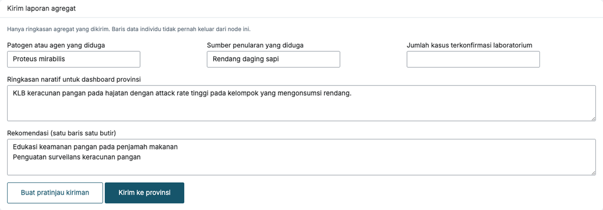

Isian sebelum pengiriman

Isi patogen dan sumber yang diduga, jumlah konfirmasi laboratorium, ringkasan naratif, serta rekomendasi. Lalu klik **Buat pratinjau kiriman**.

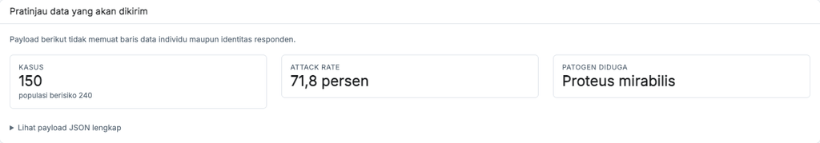

Pratinjau isi kiriman

**Periksa pratinjau ini dengan teliti.** Anda dapat membuka payload JSON lengkap untuk memastikan isinya. Payload dibentuk dari hasil analisis, bukan dari data individu, sehingga tidak memuat baris responden maupun identitas.

Setelah yakin, klik **Kirim ke provinsi**, lalu setujui kotak konfirmasi. Riwayat pengiriman tercatat beserta statusnya.

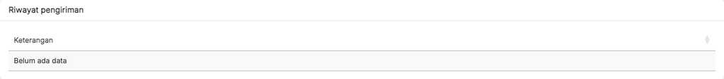

Riwayat pengiriman

# 10 Memakai dashboard provinsi

## 10.1 Ringkasan wilayah

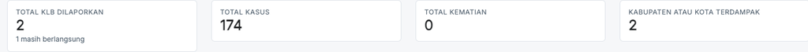

Kartu ringkasan provinsi

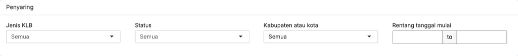

Penyaring dashboard

Penyaring memungkinkan Anda melihat KLB menurut jenis, status, kabupaten atau kota, dan rentang tanggal mulai.

## 10.2 Peta dan tren

[figure not shown]

Sebaran KLB di wilayah provinsi

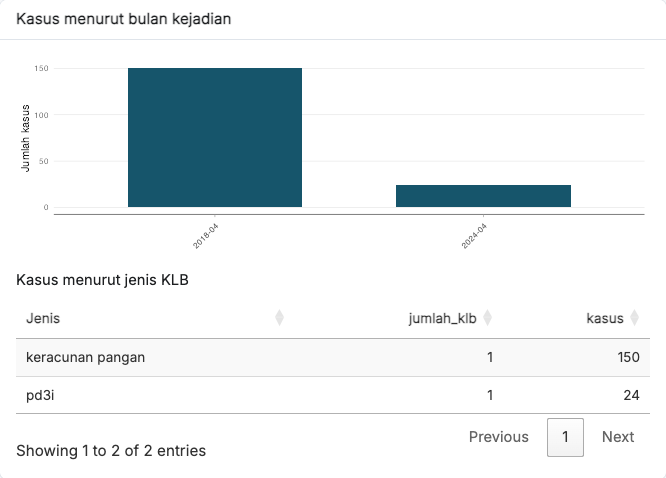

Kasus menurut bulan kejadian

Ukuran lingkaran pada peta mengikuti jumlah kasus. Warna merah menandai KLB yang masih berlangsung.

## 10.3 Rekapitulasi dan rincian

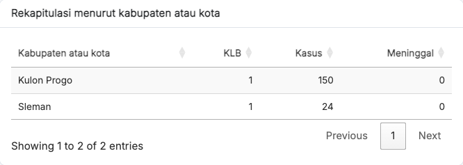

Rekapitulasi menurut kabupaten atau kota

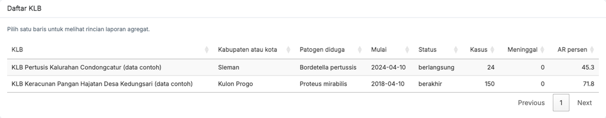

Daftar seluruh KLB

Klik satu baris untuk melihat rincian laporan agregat yang dikirim node.

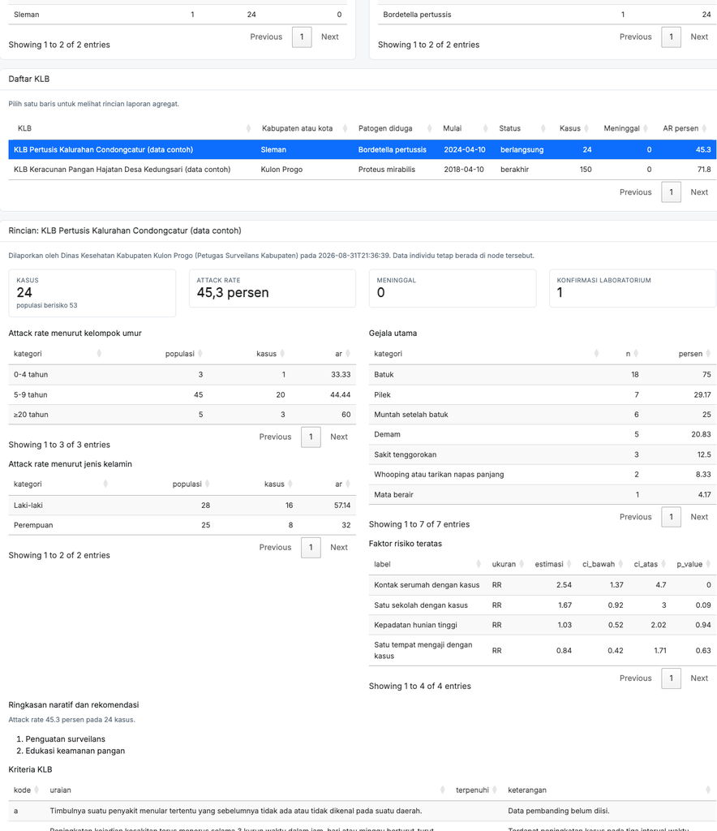

Rincian satu KLB

# 11 Analisis langsung dari konsol R

Seluruh fungsi analisis dapat dipakai di luar aplikasi, misalnya di dalam dokumen Quarto untuk keperluan penulisan manuskrip.

```r
contoh <- contoh_keracunan_pangan()
hasil <- analisis_klb(
  contoh$data, contoh$pemetaan, contoh$konfigurasi,
  jenis = "keracunan_pangan"
)

kolom <- c("label", "ar_terpapar", "ar_tak_terpapar", "arr",
           "ukuran", "estimasi", "ci_bawah", "ci_atas", "p_value")
paparan <- hasil$paparan[, kolom]

names(paparan) <- c("Jenis pangan", "AR terpapar", "AR tidak terpapar",
                    "ARR", "Ukuran", "Estimasi", "CI bawah", "CI atas",
                    "Nilai p")
knitr::kable(paparan, digits = 2)
```

| Jenis pangan | AR terpapar | AR tidak terpapar | ARR | Ukuran | Estimasi | CI bawah | CI atas | Nilai p |
| --- | --- | --- | --- | --- | --- | --- | --- | --- |
| Nasi | 73.84 | 62.16 | 1.19 | RR | 1.19 | 0.91 | 1.55 | 0.15 |
| Rendang daging sapi | 90.18 | 6.52 | 13.83 | RR | 13.83 | 4.62 | 41.35 | 0.00 |
| Oseng telur puyuh | 73.72 | 68.06 | 1.08 | RR | 1.08 | 0.90 | 1.31 | 0.39 |
| Acar | 76.47 | 65.56 | 1.17 | RR | 1.17 | 0.97 | 1.40 | 0.08 |
| Semangka | 76.19 | 68.80 | 1.11 | RR | 1.11 | 0.94 | 1.31 | 0.24 |
| Es krim | 60.71 | 75.82 | 0.80 | RR | 0.80 | 0.64 | 1.01 | 0.03 |
| Air mineral | 76.67 | 70.95 | 1.08 | RR | 1.08 | 0.87 | 1.34 | 0.52 |
| Teh manis | 71.11 | 72.97 | 0.97 | RR | 0.97 | 0.82 | 1.16 | 0.77 |

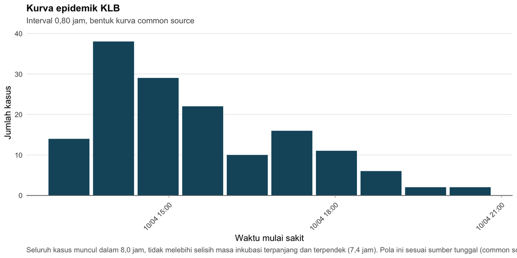

Kurva epidemik yang dihasilkan langsung dari konsol R

```r
plot_kurva_epidemik(hasil)
```

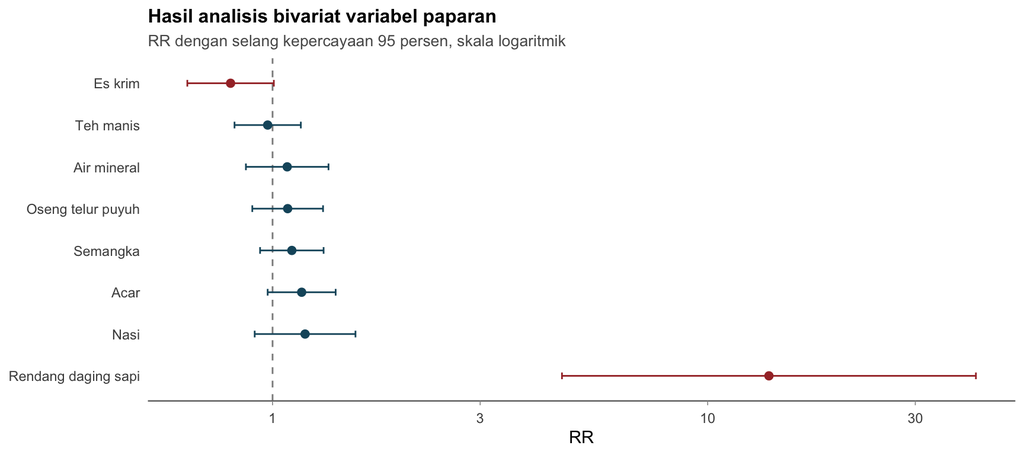

Estimasi risk ratio beserta selang kepercayaan 95 persen

```r
plot_paparan(hasil$paparan)
```

Menyusun dan mengekspor laporan juga dapat dilakukan dari konsol.

```r
naskah <- susun_draf_laporan(hasil, contoh$keterangan, metadata_laporan())
ekspor_docx(hasil, contoh$keterangan, naskah, "laporan-klb.docx")
```

Untuk data Anda sendiri, susun pemetaan seperti berikut lalu periksa kelengkapannya.

```r
pemetaan <- list(
  status_sakit    = list(kolom = "status", nilai_positif = "sakit"),
  tanggal_onset   = list(kolom = "tgl_onset"),
  tanggal_paparan = list(kolom = "tgl_makan"),
  umur            = list(kolom = "umur"),
  jenis_kelamin   = list(
    kolom = "jk",
    peta_nilai = list(L = "Laki-laki", P = "Perempuan")
  ),
  wilayah         = list(kolom = "dusun"),
  lokasi_paparan  = list(kolom = "tempat_makan"),
  gejala          = list(
    kolom = c("gjl_diare", "gjl_mual"),
    nilai_positif = "1",
    label = list(gjl_diare = "Diare", gjl_mual = "Mual")
  ),
  makanan         = list(
    kolom = c("mkn_nasi", "mkn_rendang"),
    nilai_positif = "1",
    label = list(mkn_nasi = "Nasi", mkn_rendang = "Rendang")
  )
)

periksa <- periksa_pemetaan("keracunan_pangan", pemetaan)
periksa$lengkap
```

```
[1] TRUE
```

# 12 Pemecahan masalah

| Gejala | Kemungkinan penyebab | Yang perlu dilakukan |
| --- | --- | --- |
| Tombol pada suatu tab tidak berbuat apa apa | Belum ada investigasi yang dipilih | Kembali ke tab Investigasi, klik satu baris |
| Pesan “Investigasi ini belum ditautkan ke proyek KoboToolbox” | Proyek belum ditautkan | Muat daftar proyek, klik satu baris proyek, klik Tautkan proyek terpilih |
| Pesan “KoboToolbox membalas 401” | Token API salah atau kedaluwarsa | Perbarui token pada menu Pengaturan |
| Pesan “KoboToolbox membalas 403” | Akun pemilik token tidak punya akses | Minta pemilik proyek membagikan proyek ke akun tersebut |
| Pesan “KoboToolbox membalas 404” | Proyek tidak ada, belum di-deploy, atau server berbeda | Periksa proyek di KoboToolbox dan URL server pada Pengaturan |
| Tombol Jalankan analisis mati | Variabel wajib belum lengkap | Lengkapi pada tab Pemetaan variabel sampai statusnya hijau |
| Daftar model bahasa kosong | Peramban lama dari cache, atau tidak ada internet | Muat ulang halaman sambil menahan Shift, pastikan terhubung internet |
| Model bahasa tidak dapat dimuat | Peramban tidak mendukung WebGPU | Pakai Chrome atau Edge terbaru, atau cukup pakai draf template |
| Pengiriman ke provinsi gagal | URL atau kunci API salah, atau aplikasi provinsi mati | Periksa Pengaturan, pastikan dashboard provinsi berjalan |
| Perubahan package tidak terasa setelah pembaruan | Sesi R lama masih memuat versi sebelumnya | Tutup sesi R, buka baru, jalankan aplikasi lagi |

# 13 Lampiran

## 13.1 Daftar lengkap peran variabel

```r
p <- peran_variabel()[, c("key", "label", "wajib_untuk", "dibutuhkan_oleh")]
names(p) <- c("Kunci", "Peran variabel", "Wajib untuk", "Dibutuhkan oleh analisis")
knitr::kable(p)
```

| Kunci | Peran variabel | Wajib untuk | Dibutuhkan oleh analisis |
| --- | --- | --- | --- |
| id_kasus | ID responden |  | Line listing, penelusuran kasus |
| status_sakit | Status kasus (sakit atau tidak sakit) | keracunan_pangan,penyakit_menular,pd3i | Attack rate, seluruh analisis analitik, kurva epidemik |
| klasifikasi_kasus | Klasifikasi kasus (suspek, probable, konfirmasi, carrier) | penyakit_menular,pd3i | Distribusi kasus menurut definisi kasus |
| tanggal_onset | Tanggal atau waktu mulai sakit | keracunan_pangan,penyakit_menular,pd3i | Kurva epidemik, masa inkubasi, periode KLB |
| jam_onset | Jam mulai sakit bila terpisah dari tanggal |  | Kurva epidemik satuan jam |
| tanggal_paparan | Tanggal atau waktu paparan (waktu makan) | keracunan_pangan | Masa inkubasi, periode paparan, penetapan etiologi |
| jam_paparan | Jam paparan bila terpisah dari tanggal |  | Masa inkubasi satuan jam |
| umur | Umur dalam tahun | keracunan_pangan,penyakit_menular,pd3i | Attack rate menurut kelompok umur |
| tanggal_lahir | Tanggal lahir |  | Attack rate menurut kelompok umur |
| jenis_kelamin | Jenis kelamin | keracunan_pangan,penyakit_menular,pd3i | Attack rate menurut jenis kelamin |
| wilayah | Wilayah tempat tinggal (dusun, desa, RT) | keracunan_pangan,penyakit_menular,pd3i | Attack rate menurut tempat, spot map |
| lokasi_paparan | Lokasi atau cara paparan | keracunan_pangan | Attack rate menurut tempat makan atau asal pangan |
| gejala | Tanda dan gejala | keracunan_pangan,penyakit_menular,pd3i | Tabel distribusi gejala, diagnosis banding |
| makanan | Jenis pangan yang dikonsumsi | keracunan_pangan | Tabel makan dan tidak makan, ARR, RR atau OR, analisis multivariabel |
| faktor_risiko | Faktor risiko non pangan | penyakit_menular | Analisis analitik RR atau OR |
| status_imunisasi | Status imunisasi | pd3i | Attack rate menurut status imunisasi |
| meninggal | Status meninggal |  | CFR, kriteria KLB huruf f |
| hasil_lab | Hasil pemeriksaan laboratorium |  | Tabel hasil laboratorium, klasifikasi kasus konfirmasi |
| jenis_spesimen | Jenis spesimen |  | Tabel hasil laboratorium |
| tempat_berobat | Tempat berobat |  | Distribusi pencarian pengobatan |
| pekerjaan_status | Status atau pekerjaan |  | Attack rate menurut status |
| latitude | Lintang |  | Spot map |
| longitude | Bujur |  | Spot map |
| geopoint | Titik koordinat gabungan Kobo |  | Spot map |
| kontak_kasus | Hubungan epidemiologi atau kontak dengan kasus |  | Pohon penularan, klasifikasi probable |

## 13.2 Butir checklist laporan

```r
cl <- checklist_laporan()[, c("bagian", "judul", "berlaku")]
names(cl) <- c("Bagian laporan", "Butir", "Berlaku pada laporan")
knitr::kable(cl)
```

| Bagian laporan | Butir | Berlaku pada laporan |
| --- | --- | --- |
| Bagian awal | Cover atau sampul | keduanya |
| Bagian awal | Lembar pengesahan | akhir |
| Bagian awal | Intisari dan abstract | keduanya |
| Pendahuluan | Kronologi awal | keduanya |
| Pendahuluan | Tujuan investigasi | keduanya |
| Metode | Cara penemuan kasus | keduanya |
| Metode | Definisi kasus | keduanya |
| Metode | Sampel dan rencana pemeriksaan laboratorium | sementara |
| Hasil | Deskripsi populasi berisiko dan jumlah kasus | keduanya |
| Hasil | Tabel distribusi gejala | keduanya |
| Hasil | Tabel distribusi menurut jenis kelamin | keduanya |
| Hasil | Tabel distribusi menurut kelompok umur | keduanya |
| Hasil | Tabel distribusi menurut tempat | keduanya |
| Hasil | Kurva epidemik | keduanya |
| Hasil | Tabel distribusi pangan dan attack rate ratio | keduanya |
| Hasil | Tabel diagnosis banding | keduanya |
| Hasil | Hasil uji laboratorium | keduanya |
| Hasil | Analisis lanjutan | akhir |
| Hasil | Studi lingkungan | keduanya |
| Pembahasan | Diskusi atau pembahasan | akhir |
| Pembahasan | Upaya pengendalian dan pencegahan | keduanya |
| Hasil | Penetapan KLB menurut Permenkes 1501 Tahun 2010 | keduanya |
| Penutup | Kesimpulan | keduanya |
| Penutup | Rekomendasi dan saran | keduanya |

## 13.3 Tabel rujukan agen penyebab

```r
rp <- rujukan_patogen()[, c("nama", "inkubasi_min_jam", "inkubasi_maks_jam", "perlu_verifikasi")]
names(rp) <- c("Agen penyebab", "Inkubasi minimum (jam)", "Inkubasi maksimum (jam)", "Perlu verifikasi")
knitr::kable(rp)
```

| Agen penyebab | Inkubasi minimum (jam) | Inkubasi maksimum (jam) | Perlu verifikasi |
| --- | --- | --- | --- |
| Keracunan histamin (skombroid) | 0.08 | 2.0 | FALSE |
| Keracunan monosodium glutamat | 0.08 | 1.0 | FALSE |
| Keracunan natrium hidroksida | 0.02 | 0.5 | FALSE |
| Proteus mirabilis | 0.67 | 9.0 | FALSE |
| Klebsiella pneumoniae | 5.00 | 19.0 | FALSE |
| Pseudomonas sp. | 24.00 | 72.0 | FALSE |
| Clostridium perfringens | 8.00 | 22.0 | FALSE |
| Vibrio parahaemolyticus | 2.00 | 48.0 | FALSE |
| Shigella dysenteriae | 12.00 | 96.0 | TRUE |
| Staphylococcus aureus (enterotoksin) | 0.50 | 8.0 | TRUE |
| Bacillus cereus tipe emetik | 0.50 | 6.0 | TRUE |
| Bacillus cereus tipe diare | 6.00 | 15.0 | TRUE |
| Salmonella spp. non tifoid | 6.00 | 72.0 | TRUE |
| Escherichia coli patogen | 24.00 | 240.0 | TRUE |
| Norovirus | 12.00 | 48.0 | TRUE |
| Clostridium botulinum | 12.00 | 72.0 | TRUE |
| Pestisida organofosfat seperti malation | 0.25 | 12.0 | TRUE |

## 13.4 Acuan

| Dokumen | Dipakai untuk |
| --- | --- |
| Pedoman Penyelidikan dan Penanggulangan KLB Penyakit Menular dan Keracunan Pangan, Kementerian Kesehatan, Edisi Revisi III Tahun 2020 | Kriteria KLB, langkah penyelidikan, analisis orang tempat waktu, kurva epidemik, aturan penyingkiran etiologi |
| Peraturan Menteri Kesehatan Nomor 1501 Tahun 2010 | Tujuh kriteria penetapan KLB |
| Checklist Laporan KLB Keracunan Makanan | Panel kelengkapan laporan dan tabel wajib |
| Panduan Penulisan Laporan KLB | Struktur bab laporan format IMRAD |

## 13.5 Informasi versi

| Keterangan | Nilai |
| --- | --- |
| Versi package | 0.1.0 |
| Versi R | 4.5.2 |
| Sistem operasi | aarch64-apple-darwin20 |
| Tanggal panduan disusun | 31 August 2026 |

Kode sumber, laporan masalah, dan versi terbaru tersedia di https://github.com/wmaula/klbfederated.